# Closest String Problem

## General info

In theoretical computer science, the closest string is an NP-hard computational problem, which tries to find the geometrical center of a set of input strings.

To understand the word "center", it is necessary to define a distance between two strings. Usually, this problem is studied with the Hamming distance in mind.

The closest string problem find applications in PCR primer design, genetic probe design, motif finding, and antisense drug design.

Given n length-m strings s1, s2, ..., sn, the closest string problem seeks for a new length-m string s such that d(s,si) ≤ k for all i, where d denotes the Hamming distance, and where k is as small as possible.

## Hamming distance

The Hamming distance between two equal-length strings of symbols is the number of positions at which the corresponding symbols are different.  
For example, the Hamming distance between:  
"c**a**t" and "c**u**t" is 1.

## Libraries

We need numpy library to create arrays, pygad to implement genetic algorithm, pyswarms to implement algorithms based on swarm intelligence techniques, time to measure the execution time of algorithms, matplotlib and pyswarms.utils.plotters to create cost history plot.

```python
import numpy as np
import pygad
import pyswarms as ps
import time
from matplotlib import pyplot as plt
from pyswarms.utils.plotters import plot_cost_history
```

# Genetic algorithm

A genetic algorithm (GA) is a metaheuristic inspired by the process of natural selection. Genetic algorithms are commonly used to generate high-quality solutions to optimization and search problems by relying on biologically inspired operators such as mutation, crossover and selection.

## Fitness and hamming distance function

The **hamming_distance** function calculates the Hamming distance between a candidate string (solution) and a target string (one of input_strings). This function iterates over the characters of the candidate and target strings and increments a counter l whenever it finds a position where the two strings have different symbols. The final value of l is returned as the Hamming distance.  
The **closest_string_fitness** function takes a candidate solution and an index solution_idx as input. It converts candidate's ASCII codes to characters using the chr function. It then iterates over the target strings in a list input_strings and calculates the Hamming distance between each target string and the candidate string using the hamming_distance function. The maximum Hamming distance over all target strings is then returned as the fitness of the candidate solution.  
The fitness function in **closest_string_fitness** is returned as the negative of the maximum Hamming distance because this is a maximization problem, we want to find a candidate string that is as close as possible to the target strings and has the smallest number of differences. We can use a minimization to search for the optimal solution.

```python
def hamming_distance(target_string, solution):
    l = 0
    for i in range(0,len(solution)):
        if target_string[i]!= solution[i]:
            l+=1
    return l

def closest_string_fitness(solution, solution_idx):
    candidate_string=""
    for s in solution:
        candidate_string += chr(s)
    max=0
    hamming_dist = 0
    for target_string in input_strings:
        hamming_dist= hamming_distance(target_string, candidate_string)
        if(hamming_dist>max):
            max=hamming_dist
    fitness = -(max)
    return fitness
```

## Helper functions

returnResult and averageInfo functions are defined not to repeat the same code.  
**returnResult** prints parameters and fitness value of the best solution and then converts ASCII codes to characters and presents best candidate string.  
**averageInfo** prints average time and number of solved cases.

```python
def returnResult(solution, solution_fitness):
    print("Parameters of the best solution : {solution}".format(solution=solution))
    print("Fitness value of the best solution = {solution_fitness}".format(
        solution_fitness=solution_fitness))
    best_string = ''.join([chr(s) for s in solution])
    print("Best candidate string: ", best_string)
```

```python
def averageInfo(times, solved):
    average_time = sum(times) / len(times)
    print("Average time in seconds: ", average_time)

    print("Solved "+str(solved)+"/100")
```

## Parameters of genetic algorithm

**mutation_type** is set to "random", which means that a random mutation will be applied to a randomly selected gene in an individual in the population.

**parent_selection_type** it is set to "sss", which stands for "steady-state selection". This means that new individuals are generated one at a time, and each new individual is created by selecting two parents from the current population.

**crossover_type** is set to "single_point", which means that a single crossover point is chosen at random, and the genes beyond that point in each parent are swapped to produce two offspring.

**keep_parents** is set to 50, which means that the top 50 parents with the highest fitness values will be kept in the population, while the rest will be replaced with new offspring generated through crossover and mutation.

```python
mutation_type = "random"
parent_selection_type = "sss"
crossover_type = "single_point"
mutation_probability = 0.1
keep_parents = 50
```

## Gene space

Gene space is declared as a NumPy array that contains the integer values corresponding to the ASCII code of each unique character in the input_strings.

Since the strings are made up of characters, the genetic algorithm needs a way to represent characters as numerical values that can be manipulated mathematically. By converting each unique character to its corresponding integer value in the gene_space, the genetic algorithm can operate on the strings as arrays of integers.

We use unique_chars in the gene_space to ensure that the genetic algorithm only generates solutions that contain characters that exist in the input_strings. By creating a set of all the unique characters in the input_strings, we can be sure that any character in a solution generated by the genetic algorithm will be a valid character from the original input.

## Small Input no. 1

**num_parents_mating** specifies the number of parents that will be selected for mating in each generation.

**population_size** specifies the size of the population of individuals in each generation.

**num_generations** specifies the number of generations for which the genetic algorithm will run.

**mutation_percent_genes** specifies the percentage of genes in an individual that will be mutated during reproduction.

**input_strings** is a list of target strings that the genetic algorithm will try to match. input_strings is defined as array that contains 5 elements, each string has 3 characters.

**string_length** is the length of each target string.

**unique_chars** is a set of all unique characters in the input strings.

```
Parameters of the best solution : [79 79 79]
Fitness value of the best solution = -1
Best candidate string:  OOO
```

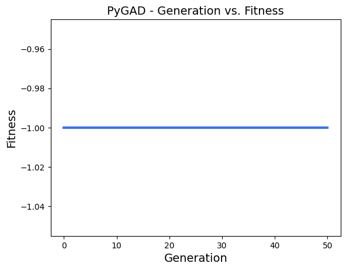

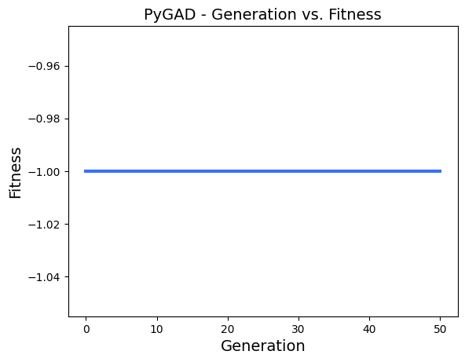

```python
num_parents_mating = 75
population_size = 150
num_generations = 50
mutation_percent_genes = 15

input_strings = ["OOI", "OIO", "OOI", "OOO", "OOI"]
string_length = len(input_strings[0])


unique_chars = set(''.join(input_strings))
gene_space = np.array([ord(c) for c in unique_chars])

ga_instance = pygad.GA(gene_space=gene_space,
                       initial_population=None,
                       num_generations=num_generations,
                       num_parents_mating=num_parents_mating,
                       fitness_func=closest_string_fitness,
                       sol_per_pop=population_size,
                       num_genes=string_length,
                       gene_type=int,
                       parent_selection_type=parent_selection_type,
                       keep_parents=keep_parents,
                       crossover_type=crossover_type,
                       mutation_type=mutation_type,mutation_percent_genes=mutation_percent_genes)


ga_instance.run()

solution, solution_fitness, solution_idx = ga_instance.best_solution()

returnResult(solution, solution_fitness)

ga_instance.plot_fitness()
```

### Output

The best solution has a string of three characters, which is represented by the array [79 79 79]. In ASCII code, the value 79 corresponds to the uppercase letter "O", so this array represents the string "OOO".

Every generation has a fitness value of -1, it suggests that the genetic algorithm has found a good solution in the very first generation.

The fitness value of the best solution is -1, which is the highest possible fitness value in this problem. This number means that the biggest difference between candidate string and input_strings is 1. We could confirm it by counting hamming distance between input_strings and candidate string, hamming distance between:  
OOI and OOO is 1  
OIO and OOO is 1  
OOI and OOO is 1  
OOO and OOO is 0  
OOI and OOO is 1

## Small input no. 2

input_strings is defined as an array that contains 5 elements, each string has 4 characters.

```
Parameters of the best solution : [88 86 87 87]
Fitness value of the best solution = -2
Best candidate string:  XVWW
```

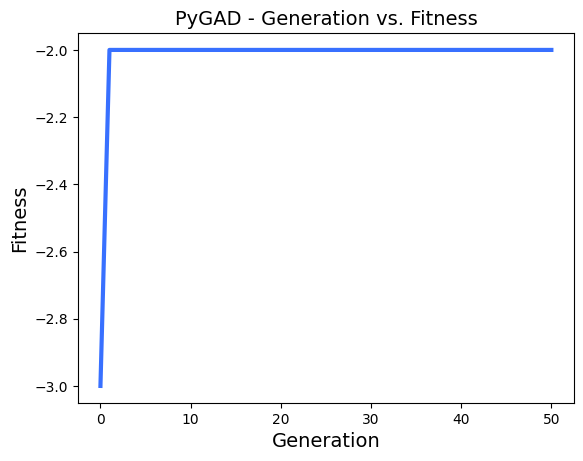

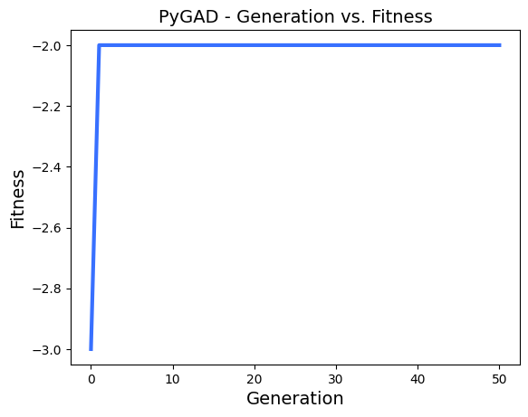

```python
num_parents_mating = 75
population_size = 150
num_generations = 50
mutation_percent_genes = 10

input_strings = ["UVWX", "XUWV", "XVWU", "UVWU", "UVXW"]
string_length = len(input_strings[0])


unique_chars = set(''.join(input_strings))
gene_space = np.array([ord(c) for c in unique_chars])


ga_instance = pygad.GA(gene_space=gene_space,
                       initial_population=None,
                       num_generations=num_generations,
                       num_parents_mating=num_parents_mating,
                       fitness_func=closest_string_fitness,
                       sol_per_pop=population_size,
                       num_genes=string_length,
                       gene_type=int,
                       parent_selection_type=parent_selection_type,
                       keep_parents=keep_parents,
                       crossover_type=crossover_type,
                       mutation_type=mutation_type,mutation_percent_genes=mutation_percent_genes)


ga_instance.run()

solution, solution_fitness, solution_idx = ga_instance.best_solution()

returnResult(solution, solution_fitness)

ga_instance.plot_fitness()
```

### Output

Genetic algorithm started with solution that hamming distance of string compared to every element in input_strings was 3. In later generations it improved to 2 different characters. Therefore, the best candidate string found by the genetic algorithm is "XVWW".

## Small input no. 3

input_strings is defined as an array that contains 5 elements, each string has 5 characters.

```
Parameters of the best solution : [71 72 83 75 79]
Fitness value of the best solution = -3
Best candidate string:  GHSKO
```

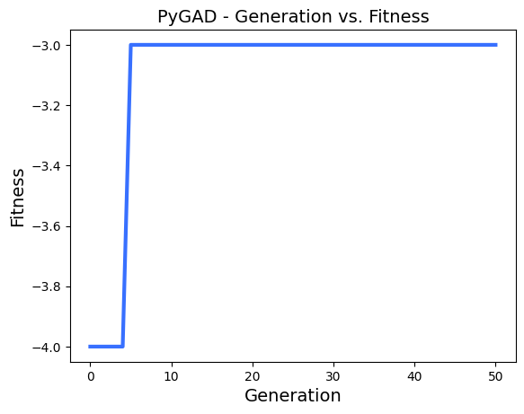

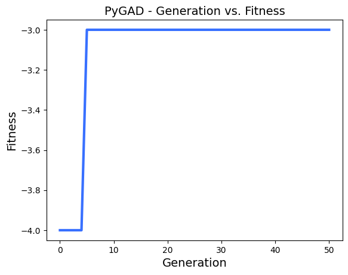

```python
num_parents_mating = 75
population_size = 150
num_generations = 50
mutation_percent_genes = 10

input_strings = ["GHJKO", "GYOPO", "GHCVO", "SHJKL", "PHJKO"]

string_length = len(input_strings[0])


unique_chars = set(''.join(input_strings))
gene_space = np.array([ord(c) for c in unique_chars])


ga_instance = pygad.GA(gene_space=gene_space,
                       initial_population=None,
                       num_generations=num_generations,
                       num_parents_mating=num_parents_mating,
                       fitness_func=closest_string_fitness,
                       sol_per_pop=population_size,
                       num_genes=string_length,
                       gene_type=int,
                       parent_selection_type=parent_selection_type,
                       keep_parents=keep_parents,
                       crossover_type=crossover_type,
                       mutation_type=mutation_type,mutation_percent_genes=mutation_percent_genes)


ga_instance.run()

solution, solution_fitness, solution_idx = ga_instance.best_solution()

returnResult(solution, solution_fitness)

ga_instance.plot_fitness()
```

### Output

The genetic algorithm initially began with a solution which string differed by 4 characters from every element in the input_strings. However it was able to improve this initial solution by reducing the number of differing characters to just 3. Therefore, the best candidate string found by the genetic algorithm is "GHSKO".

## Medium input no. 1

num_parent_mating was increased to 400, population size to 800 and num_generations to 100 to increasing the chances of finding a better solution and increase the diversity of the offspring. input_strings is defined as an array that contains 10 elements, each string has 9 characters.

```
Parameters of the best solution : [66 89 68 89 83 74 83 65 66]
Fitness value of the best solution = -7
Best candidate string:  BYDYSJSAB
```

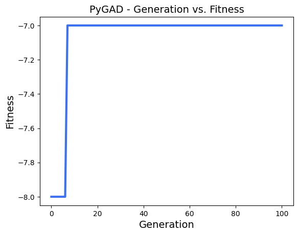

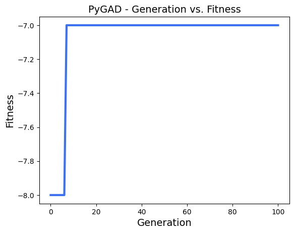

```python
num_parents_mating = 400
population_size = 800
num_generations = 100
mutation_percent_genes = 10

input_strings = ["BARACADAB", "ABRAACDAB", "RBRACADAB", "ACRACADAB", "ABRADADAB", "AJRAJKDAB", "ABUISJADR", "ABRAACDAB", "JUDBSTYUI","DFSYIJBHJ"]
string_length = len(input_strings[0])

unique_chars = set(''.join(input_strings))
gene_space = np.array([ord(c) for c in unique_chars])

ga_instance = pygad.GA(gene_space=gene_space,
                       initial_population=None,
                       num_generations=num_generations,
                       num_parents_mating=num_parents_mating,
                       fitness_func=closest_string_fitness,
                       sol_per_pop=population_size,
                       num_genes=string_length,
                       gene_type=int,
                       parent_selection_type=parent_selection_type,
                       keep_parents=keep_parents,
                       crossover_type=crossover_type,
                       mutation_type=mutation_type,mutation_percent_genes=mutation_percent_genes)


ga_instance.run()

solution, solution_fitness, solution_idx = ga_instance.best_solution()

returnResult(solution, solution_fitness)

ga_instance.plot_fitness()
```

### Output

The genetic algorithm initially began with a solution which string differed by 8 characters from every element in the input_strings. However it was able to improve this initial solution by reducing the number of differing characters to just 7. Therefore, the best candidate string found by the genetic algorithm is "BYDYSJSAB".

## Medium input no. 2

input_strings is defined as an array that contains 10 elements, each string has 10 characters.

```
Parameters of the best solution : [69 88 86 65 74 74 84 81 86 72]
Fitness value of the best solution = -6
Best candidate string:  EXVAJJTQVH
```

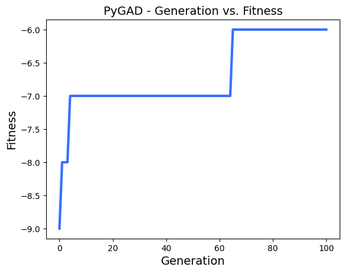

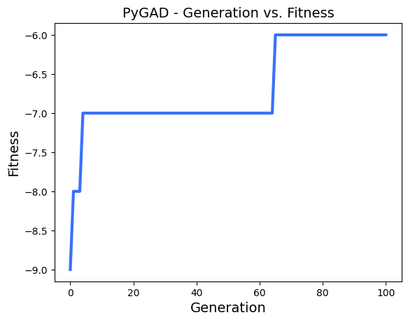

```python
num_parents_mating = 400
population_size = 800
num_generations = 100
mutation_percent_genes = 10

input_strings = ['ENVAGWCQQU', 'EIVATWZQVU', 'EAVATFRDVU', 'EXVATFXDKH', 'EXBVTJXZKH', 'EXBFLJXZZH', 'EJQFLJTZZH', 'EIQFNJTAWH', 'EREFJJTAFH', 'ELBPJITAFH']


string_length = len(input_strings[0])

unique_chars = set(''.join(input_strings))
gene_space = np.array([ord(c) for c in unique_chars])

ga_instance = pygad.GA(gene_space=gene_space,
                       initial_population=None,
                       num_generations=num_generations,
                       num_parents_mating=num_parents_mating,
                       fitness_func=closest_string_fitness,
                       sol_per_pop=population_size,
                       num_genes=string_length,
                       gene_type=int,
                       parent_selection_type=parent_selection_type,
                       keep_parents=keep_parents,
                       crossover_type=crossover_type,
                       mutation_type=mutation_type,mutation_percent_genes=mutation_percent_genes)


ga_instance.run()

solution, solution_fitness, solution_idx = ga_instance.best_solution()

returnResult(solution, solution_fitness)

ga_instance.plot_fitness()
```

### Output

Plot suggests that the algorithm was making progress towards finding a better solution over time. It started with 9 differences and ended with 6. It found best candidate string EXVAJJTQVH.

## Medium input no. 3

input_strings is defined as an array that contains 10 elements, each string has 10 characters.

```
Parameters of the best solution : [66 77 88 67 75 65 79 75 77 73]
Fitness value of the best solution = -6
Best candidate string:  BMXCKAOKMI
```

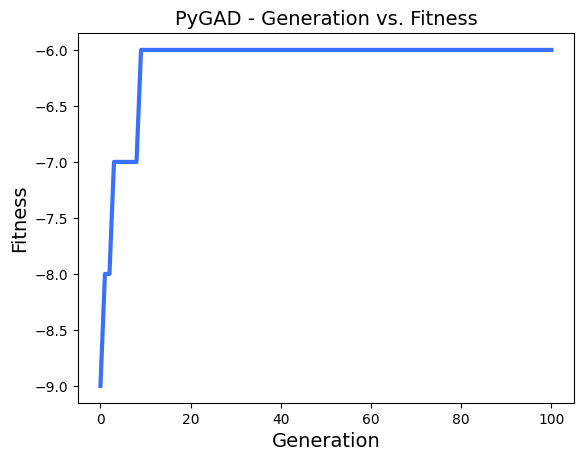

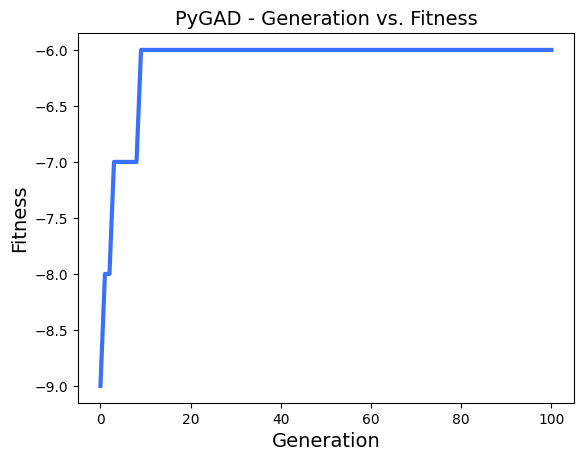

```python
num_parents_mating = 400
population_size = 800
num_generations = 100
mutation_percent_genes = 10

input_strings = ['BBXMJANTEI', 'BAXIJANOEI', 'BAXIEAOPEI', 'BAXIEAOKSU', 'BUXIMQOKSU', 'BCXWMQOKSU', 'BCXWKQOKSD', 'NMXWKWOKSD', 'FMXWKWLKSF', 'FMXOKWLKTO']


string_length = len(input_strings[0])

unique_chars = set(''.join(input_strings))
gene_space = np.array([ord(c) for c in unique_chars])

ga_instance = pygad.GA(gene_space=gene_space,
                       initial_population=None,
                       num_generations=num_generations,
                       num_parents_mating=num_parents_mating,
                       fitness_func=closest_string_fitness,
                       sol_per_pop=population_size,
                       num_genes=string_length,
                       gene_type=int,
                       parent_selection_type=parent_selection_type,
                       keep_parents=keep_parents,
                       crossover_type=crossover_type,
                       mutation_type=mutation_type,mutation_percent_genes=mutation_percent_genes)


ga_instance.run()

solution, solution_fitness, solution_idx = ga_instance.best_solution()

returnResult(solution, solution_fitness)

ga_instance.plot_fitness()
```

### Output

Plot suggests that the algorithm was making progress towards finding a better solution over time. It started with 9 differences and ended with 6. It found best candidate string BMXCKAOKMI.

## Large input no. 1

num_parent_mating was increased to 500, population size to 1000 and num_generations to 100 to increasing the chances of finding a better solution. input_strings is defined as an array that contains 20 elements, each string has 20 characters.

```
Parameters of the best solution : [82 70 82 78 72 69 65 84 90 71 71 67 78 71 75 89 68 77 82 78]
Fitness value of the best solution = -13
Best candidate string:  RFRNHEATZGGCNGKYDMRN
```

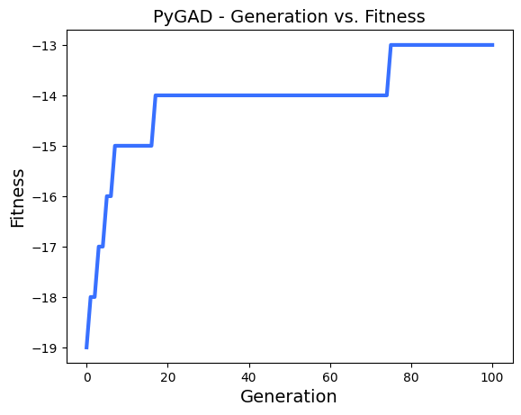

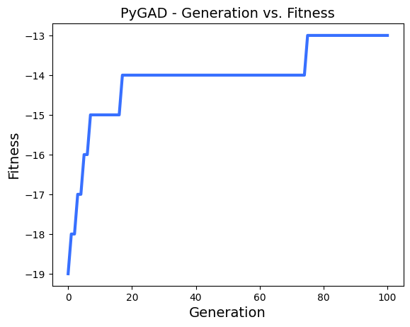

```python
num_parents_mating = 500
population_size = 1000
num_generations = 100
mutation_percent_genes = 10

input_strings = ['RCRAHWAYLRGANOXDXSRH', 'RCRAHWAYLRGRNPXUGSRH', 'RCRAHWAVLRGRNPWUGSRB', 'RCRNHWAVLAGXNPWUGSRO', 'RCRNHRAVLAQXNPWUPMRO', 'RCRNMRAVLAQXNPKUPMOO', 'RFRNMRITLAQXNPKUPMOO', 'RFANMRITSAQXNPKJQMOO', 'RFANMEITSAQMNPKJQMOW', 'RFANMEITXVQMNKKJQMOL', 'RFZNMEFTXVCMNKKJQMOA', 'RFHNMEUTXVCCNKKJVMOA', 'RFHNMFUTXPCCNKKJVMQA', 'RFHNAFZTXPCCNWKJVMQA', 'FFHNAFZTXPCCNWKRQMQF', 'FFUNAFZTXPCCNWKWQMSF', 'FFUNAFZTXQJXNWKWQMSN', 'FFUNAEZTXQPYNPKWQMSN', 'FFIDAEZTXCPYNCKWQMSN', 'FFIDFEZTXCPYNCKYVHSN']


string_length = len(input_strings[0])

unique_chars = set(''.join(input_strings))
gene_space = np.array([ord(c) for c in unique_chars])

ga_instance = pygad.GA(gene_space=gene_space,
                       initial_population=None,
                       num_generations=num_generations,
                       num_parents_mating=num_parents_mating,
                       fitness_func=closest_string_fitness,
                       sol_per_pop=population_size,
                       num_genes=string_length,
                       gene_type=int,
                       parent_selection_type=parent_selection_type,
                       keep_parents=keep_parents,
                       crossover_type=crossover_type,
                       mutation_type=mutation_type,mutation_percent_genes=mutation_percent_genes)


ga_instance.run()

solution, solution_fitness, solution_idx = ga_instance.best_solution()

returnResult(solution, solution_fitness)

ga_instance.plot_fitness()
```

### Output

Plot suggests that the algorithm was making progress towards finding a better solution over time. It started with 19 differences and ended with 13. It found best candidate string RFRNHEATZGGCNGKYDMRN.

## Large input no. 2

input_strings is defined as an array that contains 20 elements, each string has 20 characters.

```
Parameters of the best solution : [89 77 82 69 66 66 84 82 80 69 84 66 82 81 79 81 70 76 75 90]
Fitness value of the best solution = -14
Best candidate string:  YMREBBTRPETBRQOQFLKZ
```

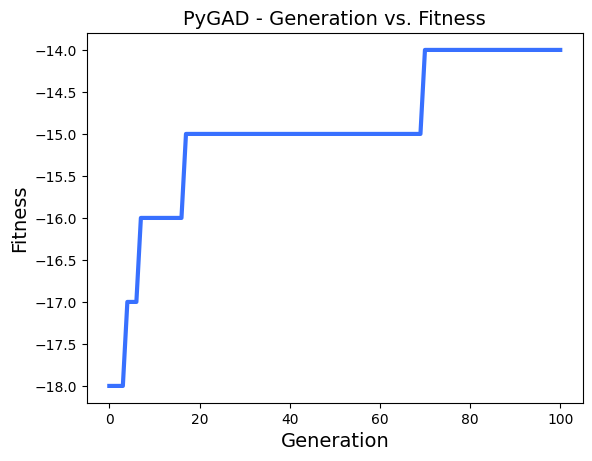

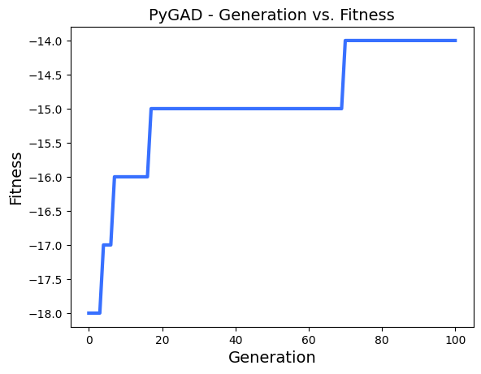

```python
num_parents_mating = 500
population_size = 1000
num_generations = 100
mutation_percent_genes = 10

input_strings = ['SMMEYBIXSFTVVLOVFNCD', 'SMVEYBIXGSTVVLONFWCD', 'SMVEYBCJGSTAVLONFWCJ', 'PGQEYBCJGETAVLONFWAJ', 'PGQEYBCJPETAVLANFZAP', 'PCHEYFCJPETAVLANFZVZ', 'EJHEYFCJPETAJUANFBVZ', 'CJSEYFCJPETAJQANKBVZ', 'JJSEYFCJPETAIQLQKBPZ', 'JJSEFFDRPETAIQSQKBPZ', 'JPREFIDRPEOAIQGQKBPZ', 'MPREXBDRPEOMIQGQKBPA', 'PPRGXBJRPEOMIQGQKBPU', 'PFRSXBQRPEOMIQGQXXPU', 'YTRSIBQRPEOTIQGQRXPU', 'YTRSYBTRPEOTIQTQRJPH', 'YTRSYOTRPEQTIQTTRVKH', 'YTRSWVTRPEQTIDTVPVKH', 'YJRWWVTRPOQTIDTLPVKE', 'YURWJVTRPCRTJDTLPVKE']


string_length = len(input_strings[0])

unique_chars = set(''.join(input_strings))
gene_space = np.array([ord(c) for c in unique_chars])

ga_instance = pygad.GA(gene_space=gene_space,
                       initial_population=None,
                       num_generations=num_generations,
                       num_parents_mating=num_parents_mating,
                       fitness_func=closest_string_fitness,
                       sol_per_pop=population_size,
                       num_genes=string_length,
                       gene_type=int,
                       parent_selection_type=parent_selection_type,
                       keep_parents=keep_parents,
                       crossover_type=crossover_type,
                       mutation_type=mutation_type,mutation_percent_genes=mutation_percent_genes)


ga_instance.run()

solution, solution_fitness, solution_idx = ga_instance.best_solution()

returnResult(solution, solution_fitness)

ga_instance.plot_fitness()
```

### Output

Plot suggests that the algorithm was making progress towards finding a better solution over time. It started with 18 differences and ended with 14. It found best candidate string YMREBBTRPETBRQOQFLKZ.

## Large input no. 3

input_strings is defined as an array that contains 20 elements, each string has 20 characters.

```
Parameters of the best solution : [78 85 82 78 68 87 79 69 66 69 78 87 73 86 74 86 70 80 80 88]
Fitness value of the best solution = -8
Best candidate string:  NURNDWOEBENWIVJVFPPX
```

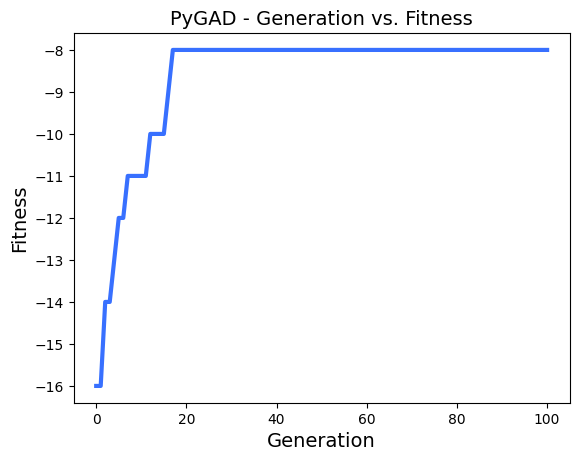

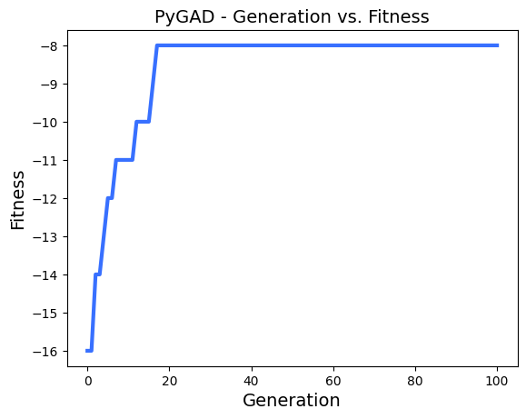

```python
num_parents_mating = 500
population_size = 1000
num_generations = 100
mutation_percent_genes = 10

input_strings = ['XQRNDWOCVENHQFNVFPPX', 'XQRNDWOCVENHIFNVFPPX', 'SQRNDWOCVENHIFNVFPPX', 'SQRNDWOCMENHIFNVFPPX', 'SQRNDWOCMENHMFNVFPPX', 'SQRNDWOCMENTMFNVFPPX', 'SQRNDWOCMENTLFNVFPPX', 'SURNDWOCMENTLFNVFPPX', 'SURNDWOCMENTQFNVFPPX', 'SURNDWOCMENTQBNVFPPX', 'SURNDWOCMENTQBJVFPPX', 'SURNDWOCMENTQBJVFGPX', 'SURNDWOCMENTQQJVFGPX', 'BURNDWOCMENTQQJVFGPX', 'BURNDWOTMENTQQJVFGPX', 'BURNDWOTMENOQQJVFGPX', 'BUGNDWOTMENOQQJVFGPX', 'VUGNDWOTMENOQQJVFGPX', 'VUGNDWOTDENOQQJVFGPX', 'VUGNDWOXDENOQQJVFGPX']


string_length = len(input_strings[0])

unique_chars = set(''.join(input_strings))
gene_space = np.array([ord(c) for c in unique_chars])

ga_instance = pygad.GA(gene_space=gene_space,
                       initial_population=None,
                       num_generations=num_generations,
                       num_parents_mating=num_parents_mating,
                       fitness_func=closest_string_fitness,
                       sol_per_pop=population_size,
                       num_genes=string_length,
                       gene_type=int,
                       parent_selection_type=parent_selection_type,
                       keep_parents=keep_parents,
                       crossover_type=crossover_type,
                       mutation_type=mutation_type,mutation_percent_genes=mutation_percent_genes)


ga_instance.run()

solution, solution_fitness, solution_idx = ga_instance.best_solution()

returnResult(solution, solution_fitness)

ga_instance.plot_fitness()
```

### Output

Plot suggests that the algorithm was making progress towards finding a better solution over time. It started with 16 differences and ended with 8. It found best candidate string NURNDWOEBENWIVJVFPPX.

## Average time, generations and solutions

To determine if a genetic algorithm is a suitable approach for our problem, we need to evaluate its accuracy and efficiency. This can be achieved by testing it on small, medium, and large inputs, and observing any decrease in accuracy rates.

### Small input

In our previous observation of the input_strings ["UVWX", "XUWV", "XVWU", "UVWU", "UVXW"] we found that the best fitness value was -2. To determine the effectiveness of our algorithm, we can run it in a loop for 100 instances and increment the "solved" counter each time the solution_fitness value equals -2.

```python
num_parents_mating = 75
population_size = 150
num_generations = 50
mutation_percent_genes = 10

input_strings = ["UVWX", "XUWV", "XVWU", "UVWU", "UVXW"]
string_length = len(input_strings[0])


unique_chars = set(''.join(input_strings))
gene_space = np.array([ord(c) for c in unique_chars])


times = []
solved = 0
for i in range(100):
    start = time.time()
    ga_instance = pygad.GA(gene_space=gene_space,
                        initial_population=None,
                        num_generations=num_generations,
                        num_parents_mating=num_parents_mating,
                        fitness_func=closest_string_fitness,
                        sol_per_pop=population_size,
                        num_genes=string_length,
                        gene_type=int,
                        parent_selection_type=parent_selection_type,
                        keep_parents=keep_parents,
                        crossover_type=crossover_type,
                        mutation_type=mutation_type,mutation_percent_genes=mutation_percent_genes)


    ga_instance.run()
    end = time.time()
    times.append(end-start)
    solution, solution_fitness, solution_idx = ga_instance.best_solution()
    if solution_fitness == -2:
        solved += 1

averageInfo(times, solved)
```

```
Average time in seconds:  0.08530545473098755
Solved 100/100
```

### Results

Based on our observation of small input, we can say that the fitness function has achieved 100% accuracy. In all 100 instances, the solutions had a fitness value of -2. The average time taken by the algorithm to find the solutions is 0.08530545473098755 seconds, which suggests that the algorithm is performing well.

### Medium input

In our previous observation of the input_strings presented below, we found that the best fitness value was -6. To determine the effectiveness of our algorithm, we can run it in a loop for 100 instances and increment the "solved" counter each time the solution_fitness value equals -6.

```python
num_parents_mating = 400
population_size = 800
num_generations = 100
mutation_percent_genes = 10

input_strings = ['ENVAGWCQQU', 'EIVATWZQVU', 'EAVATFRDVU', 'EXVATFXDKH', 'EXBVTJXZKH', 'EXBFLJXZZH', 'EJQFLJTZZH', 'EIQFNJTAWH', 'EREFJJTAFH', 'ELBPJITAFH']


string_length = len(input_strings[0])

unique_chars = set(''.join(input_strings))
gene_space = np.array([ord(c) for c in unique_chars])

times = []
solved = 0
for i in range(100):
    start = time.time()
    ga_instance = pygad.GA(gene_space=gene_space,
                        initial_population=None,
                        num_generations=num_generations,
                        num_parents_mating=num_parents_mating,
                        fitness_func=closest_string_fitness,
                        sol_per_pop=population_size,
                        num_genes=string_length,
                        gene_type=int,
                        parent_selection_type=parent_selection_type,
                        keep_parents=keep_parents,
                        crossover_type=crossover_type,
                        mutation_type=mutation_type,mutation_percent_genes=mutation_percent_genes)


    ga_instance.run()
    end = time.time()
    times.append(end-start)
    solution, solution_fitness, solution_idx = ga_instance.best_solution()
    if solution_fitness == -6:
        solved += 1

averageInfo(times, solved)
```

```
Average time in seconds:  2.1938141703605654
Solved 32/100
```

### Results

Based on our observation of medium input, we can say that the fitness function has achieved 32% accuracy. The average time taken by the algorithm to find the solutions is 2.1938141703605654 seconds. These numbers suggest that our algorithm may not perform well when dealing with medium-sized inputs.

### Large input

In our previous observation of the large input_strings presented below, we found that the best fitness value was -8. To determine the effectiveness of our algorithm, we can run it in a loop for 100 instances and increment the "solved" counter each time the solution_fitness value equals -8.

```python
num_parents_mating = 500
population_size = 1000
num_generations = 100
mutation_percent_genes = 10

input_strings = ['XQRNDWOCVENHQFNVFPPX', 'XQRNDWOCVENHIFNVFPPX', 'SQRNDWOCVENHIFNVFPPX', 'SQRNDWOCMENHIFNVFPPX', 'SQRNDWOCMENHMFNVFPPX', 'SQRNDWOCMENTMFNVFPPX', 'SQRNDWOCMENTLFNVFPPX', 'SURNDWOCMENTLFNVFPPX', 'SURNDWOCMENTQFNVFPPX', 'SURNDWOCMENTQBNVFPPX', 'SURNDWOCMENTQBJVFPPX', 'SURNDWOCMENTQBJVFGPX', 'SURNDWOCMENTQQJVFGPX', 'BURNDWOCMENTQQJVFGPX', 'BURNDWOTMENTQQJVFGPX', 'BURNDWOTMENOQQJVFGPX', 'BUGNDWOTMENOQQJVFGPX', 'VUGNDWOTMENOQQJVFGPX', 'VUGNDWOTDENOQQJVFGPX', 'VUGNDWOXDENOQQJVFGPX']


string_length = len(input_strings[0])

unique_chars = set(''.join(input_strings))
gene_space = np.array([ord(c) for c in unique_chars])

times = []
solved = 0
for i in range(100):
    start = time.time()
    ga_instance = pygad.GA(gene_space=gene_space,
                        initial_population=None,
                        num_generations=num_generations,
                        num_parents_mating=num_parents_mating,
                        fitness_func=closest_string_fitness,
                        sol_per_pop=population_size,
                        num_genes=string_length,
                        gene_type=int,
                        parent_selection_type=parent_selection_type,
                        keep_parents=keep_parents,
                        crossover_type=crossover_type,
                        mutation_type=mutation_type,mutation_percent_genes=mutation_percent_genes)


    ga_instance.run()
    end = time.time()
    times.append(end-start)
    solution, solution_fitness, solution_idx = ga_instance.best_solution()
    if solution_fitness == -8:
        solved += 1

averageInfo(times, solved)
```

```
Average time in seconds:  4.250477488040924
Solved 18/100
```

### Results

Based on our observation of large input, we can say that the fitness function has achieved 18% accuracy when desired solution_fitness equals -8. The average time taken by the algorithm to find the solutions is 4.250477488040924 seconds. These numbers suggest that our algorithm may not perform well when dealing with large-sized inputs.

Since we do not know if better fitness is possible, we could perform another test with the same input but solution_fitness set to -7.

```python
num_parents_mating = 500
population_size = 1000
num_generations = 100
mutation_percent_genes = 10

input_strings = ['XQRNDWOCVENHQFNVFPPX', 'XQRNDWOCVENHIFNVFPPX', 'SQRNDWOCVENHIFNVFPPX', 'SQRNDWOCMENHIFNVFPPX', 'SQRNDWOCMENHMFNVFPPX', 'SQRNDWOCMENTMFNVFPPX', 'SQRNDWOCMENTLFNVFPPX', 'SURNDWOCMENTLFNVFPPX', 'SURNDWOCMENTQFNVFPPX', 'SURNDWOCMENTQBNVFPPX', 'SURNDWOCMENTQBJVFPPX', 'SURNDWOCMENTQBJVFGPX', 'SURNDWOCMENTQQJVFGPX', 'BURNDWOCMENTQQJVFGPX', 'BURNDWOTMENTQQJVFGPX', 'BURNDWOTMENOQQJVFGPX', 'BUGNDWOTMENOQQJVFGPX', 'VUGNDWOTMENOQQJVFGPX', 'VUGNDWOTDENOQQJVFGPX', 'VUGNDWOXDENOQQJVFGPX']


string_length = len(input_strings[0])

unique_chars = set(''.join(input_strings))
gene_space = np.array([ord(c) for c in unique_chars])

times = []
solved = 0
for i in range(100):
    start = time.time()
    ga_instance = pygad.GA(gene_space=gene_space,
                        initial_population=None,
                        num_generations=num_generations,
                        num_parents_mating=num_parents_mating,
                        fitness_func=closest_string_fitness,
                        sol_per_pop=population_size,
                        num_genes=string_length,
                        gene_type=int,
                        parent_selection_type=parent_selection_type,
                        keep_parents=keep_parents,
                        crossover_type=crossover_type,
                        mutation_type=mutation_type,mutation_percent_genes=mutation_percent_genes)


    ga_instance.run()
    end = time.time()
    times.append(end-start)
    solution, solution_fitness, solution_idx = ga_instance.best_solution()
    if solution_fitness == -7:
        solved += 1

averageInfo(times, solved)
```

```
Average time in seconds:  4.248347134590149
Solved 73/100
```

```python
num_parents_mating = 500
population_size = 1000
num_generations = 100
mutation_percent_genes = 10

input_strings = ['XQRNDWOCVENHQFNVFPPX', 'XQRNDWOCVENHIFNVFPPX', 'SQRNDWOCVENHIFNVFPPX', 'SQRNDWOCMENHIFNVFPPX', 'SQRNDWOCMENHMFNVFPPX', 'SQRNDWOCMENTMFNVFPPX', 'SQRNDWOCMENTLFNVFPPX', 'SURNDWOCMENTLFNVFPPX', 'SURNDWOCMENTQFNVFPPX', 'SURNDWOCMENTQBNVFPPX', 'SURNDWOCMENTQBJVFPPX', 'SURNDWOCMENTQBJVFGPX', 'SURNDWOCMENTQQJVFGPX', 'BURNDWOCMENTQQJVFGPX', 'BURNDWOTMENTQQJVFGPX', 'BURNDWOTMENOQQJVFGPX', 'BUGNDWOTMENOQQJVFGPX', 'VUGNDWOTMENOQQJVFGPX', 'VUGNDWOTDENOQQJVFGPX', 'VUGNDWOXDENOQQJVFGPX']


string_length = len(input_strings[0])

unique_chars = set(''.join(input_strings))
gene_space = np.array([ord(c) for c in unique_chars])

times = []
solved = 0
for i in range(100):
    start = time.time()
    ga_instance = pygad.GA(gene_space=gene_space,
                        initial_population=None,
                        num_generations=num_generations,
                        num_parents_mating=num_parents_mating,
                        fitness_func=closest_string_fitness,
                        sol_per_pop=population_size,
                        num_genes=string_length,
                        gene_type=int,
                        parent_selection_type=parent_selection_type,
                        keep_parents=keep_parents,
                        crossover_type=crossover_type,
                        mutation_type=mutation_type,mutation_percent_genes=mutation_percent_genes)


    ga_instance.run()
    end = time.time()
    times.append(end-start)
    solution, solution_fitness, solution_idx = ga_instance.best_solution()
    if solution_fitness == -6:
        solved += 1

averageInfo(times, solved)
```

```
Average time in seconds:  4.234085736274719
Solved 3/100
```

We can say that the fitness function has achieved 3% accuracy when desired solution_fitness equals -6. These numbers suggest that our algorithm does not perform well when dealing with large-sized inputs.

# Particle swarm optimization

Is a computational method that optimizes a problem by iteratively trying to improve a candidate solution with regard to a given measure of quality. It solves a problem by having a population of candidate solutions and moving these particles around in the search-space according to simple mathematical formula over the particle's position and velocity.

## Fitness and hamming functions

**hamming_distance**: This function calculates the Hamming distance between a given target_string and a solution string.

**closest_string_fitness_swarms**: This function takes a solution string and computes its fitness by finding the maximum Hamming distance between the solution string and the set of input strings. The fitness value is returned.

**f(x)**: This function converts the input array of real numbers x into an array of integers by rounding them to the nearest integer and scaling them based on the length of unique_chars. It then calls closest_string_fitness_swarms() on each particle in the array and returns an array of the resulting fitness values.

```python
def hamming_distance(target_string, solution):
    l = 0
    for i in range(0,len(solution)):
        if target_string[i]!= solution[i]:
            l+=1
    return l

def closest_string_fitness_swarms(solution):
    candidate_string = "".join([unique_chars[s] for s in solution])
    max=0
    hamming_dist = 0
    for target_string in input_strings:
        hamming_dist= hamming_distance(target_string, candidate_string)
        if(hamming_dist>max):
            max=hamming_dist
    fitness = max
    return fitness


def f(x):
    x_int = np.round(x*(len(unique_chars)-1)).astype(int)
    n_particles = x.shape[0]
    j = [closest_string_fitness_swarms(x_int[i]) for i in range(n_particles)]
    return np.array(j)
```

## Helper function

returnResultSwarms is defined not to repeat the same code.  
**returnResultSwarms** prints cost of the best solution and converts ASCII codes to characters and presents best candidate string.  
**returnBounds** calculates the maximum and minimum bounds for each dimension of the search space based on the length of unique_chars. It creates two arrays max_bound and min_bound. The function then scales the bounds to the range [0, 1] by dividing each bound by len(unique_chars)-1, and returns the scaled bounds as a tuple rbounds. This scaling is done to work with values in the range [0, 1].

```python
def returnResultSwarms(pos, cost):
    best_string = ''.join([unique_chars[int(round(s*(len(unique_chars)-1)))] for s in pos])

    print("Best candidate string: ", best_string)
    print("Fitness value of the best solution = {solution_fitness}".format(
        solution_fitness=-int(cost)))
```

```python
def returnBounds(unique_chars, num_dimensions):
    max_bound = np.array([len(unique_chars)-1] * num_dimensions)
    min_bound = np.array([0] * num_dimensions)
    bounds = (min_bound, max_bound)
    rbounds = (bounds[0]/float(len(unique_chars)-1), bounds[1]/float(len(unique_chars)-1))
    return rbounds
```

## Options value

**c1**: 0.7, it determines how much each particle is influenced by its own best position in the search space.

**c2**: 1.3, it determines how much each particle is influenced by the best position found by its neighboring particles in the search space.

**w**: 0.5, it determines how much the particle's velocity influences its movement in the search space, balancing between exploration and exploitation.

## Small input no. 1

**num_particles** (1000) and **num_iterations** (50) specify the number of particles to be used in the swarm and the maximum number of iterations to be performed.  
**input_strings** is a list of strings used in the fitness function, input_strings is defined as array that contains 5 elements, each string has 3 characters. **num_dimensions** is the length of the first string in input_strings, which represents the number of dimensions in the search space.  
**unique_chars** is a list of the unique characters present in the input strings, which is used to calculate the bounds of the search space in the returnBounds() function.  
It creates an instance of the GlobalBestPSO class from the pyswarm package with the specified number of particles, dimensions, options, and bounds.

```
2023-04-09 12:02:01,150 - pyswarms.single.global_best - INFO - Optimize for 50 iters with {'c1': 0.7, 'c2': 1.3, 'w': 0.5}
2023-04-09 12:02:01,322 - pyswarms.single.global_best - INFO - Optimization finished | best cost: 1.0, best pos: [0.05174083 0.16301789 0.27704436]
```

```
Best candidate string:  OOO
Fitness value of the best solution = -1
```

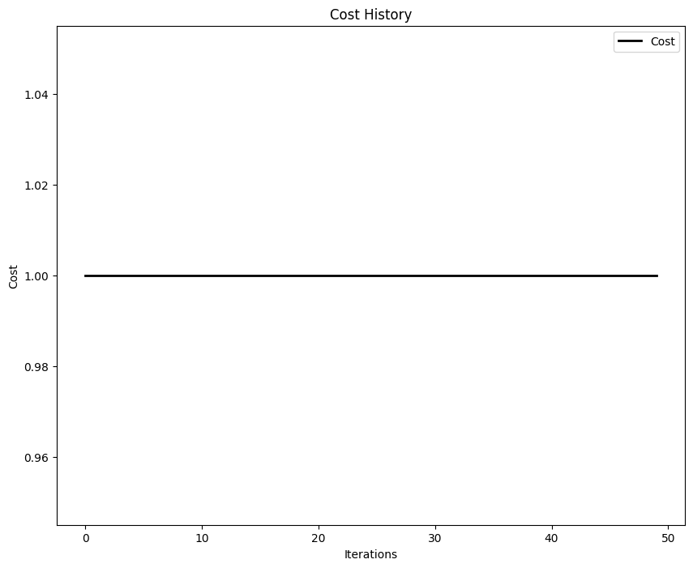

```python
num_particles = 1000
num_iterations = 50

input_strings = ["OOI", "OIO", "OOI", "OOO", "OOI"]
num_dimensions = len(input_strings[0])
unique_chars = list(set(''.join(input_strings)))
rbounds = returnBounds(unique_chars, num_dimensions)

options = {'c1': 0.7, 'c2': 1.3, 'w':0.5}


optimizer = ps.single.GlobalBestPSO(n_particles=num_particles, dimensions=num_dimensions, options=options, bounds=rbounds)
cost, pos = optimizer.optimize(f, iters=num_iterations)

returnResultSwarms(pos, cost)
cost_history = optimizer.cost_history

plot_cost_history(cost_history)
plt.show()
```

### Output

The fitness value of the best solution is -1, which is the highest possible fitness value in this problem. This number means that the biggest difference between candidate string and input_strings is 1.  
We can say that swarm particle algorithm may be effective in solving our problem because it produced the same results as the genetic algorithm.

## Small input no. 2

input_strings is defined as an array that contains 5 elements, each string has 4 characters.

```
2023-04-09 12:01:55,425 - pyswarms.single.global_best - INFO - Optimize for 50 iters with {'c1': 0.7, 'c2': 1.3, 'w': 0.5}
2023-04-09 12:01:55,654 - pyswarms.single.global_best - INFO - Optimization finished | best cost: 2.0, best pos: [0.50711229 0.88980166 0.10001667 0.88079083]
```

```
Best candidate string:  UVWV
Fitness value of the best solution = -2
```

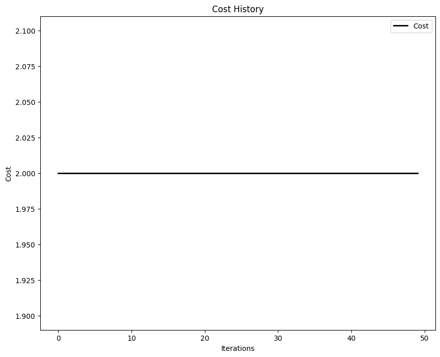

```python
num_particles = 1000
num_iterations = 50

input_strings = ["UVWX", "XUWV", "XVWU", "UVWU", "UVXW"]
num_dimensions = len(input_strings[0])
unique_chars = list(set(''.join(input_strings)))
rbounds = returnBounds(unique_chars, num_dimensions)

options = {'c1': 0.7, 'c2': 1.3, 'w':0.5}


optimizer = ps.single.GlobalBestPSO(n_particles=num_particles, dimensions=num_dimensions, options=options, bounds=rbounds)
cost, pos = optimizer.optimize(f, iters=num_iterations)

returnResultSwarms(pos, cost)
cost_history = optimizer.cost_history

plot_cost_history(cost_history)
plt.show()
```

### Output

The fitness value of the best solution is -2  
Genetic algorithm produced the same result (-2) as swarm particle algorithm.

## Small input no. 3

input_strings is defined as an array that contains 5 elements, each string has 5 characters.

```
2023-04-09 12:01:49,321 - pyswarms.single.global_best - INFO - Optimize for 50 iters with {'c1': 0.7, 'c2': 1.3, 'w': 0.5}
2023-04-09 12:01:49,563 - pyswarms.single.global_best - INFO - Optimization finished | best cost: 3.0, best pos: [0.49770476 0.12706028 0.63114617 0.82078353 0.03404978]
```

```
Best candidate string:  SHCPO
Fitness value of the best solution = -3
```

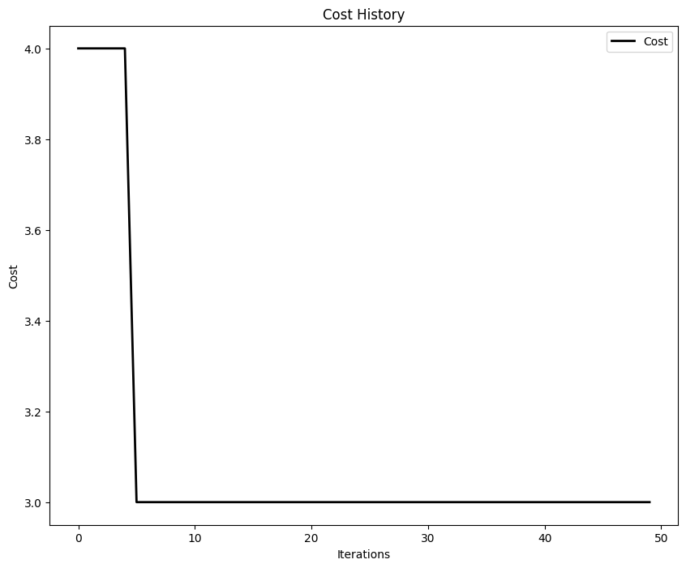

```python
num_particles = 1000
num_iterations = 50

input_strings = ["GHJKO", "GYOPO", "GHCVO", "SHJKL", "PHJKO"]
num_dimensions = len(input_strings[0])
unique_chars = list(set(''.join(input_strings)))
rbounds = returnBounds(unique_chars, num_dimensions)

options = {'c1': 0.7, 'c2': 1.3, 'w':0.5}


optimizer = ps.single.GlobalBestPSO(n_particles=num_particles, dimensions=num_dimensions, options=options, bounds=rbounds)
cost, pos = optimizer.optimize(f, iters=num_iterations)

returnResultSwarms(pos, cost)

cost_history = optimizer.cost_history

plot_cost_history(cost_history)
plt.show()
```

### Output

The algorithm initially began with a solution which string differed by 4 characters from every element in the input_strings. However it was able to improve this initial solution by reducing the number of differing characters to just 3. The genetic algorithm returned the same fitness value.  
Based on three outputs of small input strings, we can say that swarm particle algorithm solves problem with small input at least as good as genetic algorithm.

## Medium input no. 1

num_paricles is increased to 2000 and num_iterations to 100 in order to improve results. input_strings is defined as an array that contains 10 elements, each string has 9 characters.

```
2023-04-10 12:31:01,168 - pyswarms.single.global_best - INFO - Optimize for 100 iters with {'c1': 0.7, 'c2': 1.3, 'w': 0.5}
2023-04-10 12:31:02,558 - pyswarms.single.global_best - INFO - Optimization finished | best cost: 7.0, best pos: [0.78485148 0.40484735 0.97605582 0.33364755 0.20346588 0.6263072
 0.41158963 0.18434568 0.03178099]
```

```
Best candidate string:  DTRYSJTUB
Fitness value of the best solution = -7
```

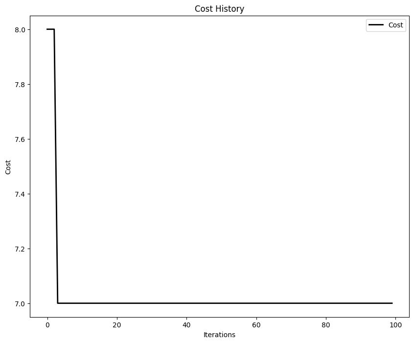

```python
num_particles = 2000
num_iterations = 100

input_strings = ["BARACADAB", "ABRAACDAB", "RBRACADAB", "ACRACADAB", "ABRADADAB", "AJRAJKDAB", "ABUISJADR", "ABRAACDAB", "JUDBSTYUI","DFSYIJBHJ"]
num_dimensions = len(input_strings[0])
unique_chars = list(set(''.join(input_strings)))
rbounds = returnBounds(unique_chars, num_dimensions)

options = {'c1': 0.7, 'c2': 1.3, 'w':0.5}


optimizer = ps.single.GlobalBestPSO(n_particles=num_particles, dimensions=num_dimensions, options=options, bounds=rbounds)
cost, pos = optimizer.optimize(f, iters=num_iterations)

returnResultSwarms(pos, cost)

cost_history = optimizer.cost_history

plot_cost_history(cost_history)
plt.show()
```

### Output

Plot suggests that the algorithm was making progress towards finding a better solution over time. It started with 8 differences and ended with 7. It found best candidate string DTRYSJTUB. It produced the same fitness value as genetic algorithm.

## Medium input no. 2

input_strings is defined as an array that contains 10 elements, each string has 10 characters.

```
2023-04-09 12:01:34,110 - pyswarms.single.global_best - INFO - Optimize for 100 iters with {'c1': 0.7, 'c2': 1.3, 'w': 0.5}
2023-04-09 12:01:35,518 - pyswarms.single.global_best - INFO - Optimization finished | best cost: 8.0, best pos: [0.99101716 0.07701017 0.35926284 0.41262303 0.71994737 0.61228899
 0.17157012 0.27463068 0.26053195 0.49147163]
```

```
Best candidate string:  ELFAUJWRIZ
Fitness value of the best solution = -8
```

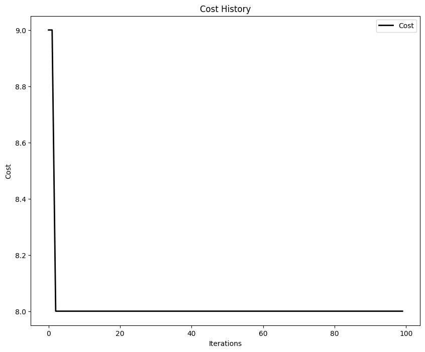

```python
num_particles = 2000
num_iterations = 100

input_strings = ['ENVAGWCQQU', 'EIVATWZQVU', 'EAVATFRDVU', 'EXVATFXDKH', 'EXBVTJXZKH', 'EXBFLJXZZH', 'EJQFLJTZZH', 'EIQFNJTAWH', 'EREFJJTAFH', 'ELBPJITAFH']
num_dimensions = len(input_strings[0])
unique_chars = list(set(''.join(input_strings)))
rbounds = returnBounds(unique_chars, num_dimensions)

options = {'c1': 0.7, 'c2': 1.3, 'w':0.5}


optimizer = ps.single.GlobalBestPSO(n_particles=num_particles, dimensions=num_dimensions, options=options, bounds=rbounds)
cost, pos = optimizer.optimize(f, iters=num_iterations)

returnResultSwarms(pos, cost)
cost_history = optimizer.cost_history

plot_cost_history(cost_history)
plt.show()
```

### Output

Plot suggests that the algorithm was making progress towards finding a better solution over time. It started with 9 differences and ended with 8.  
It produced worse (-8) fitness value than genetic algorithm (-6), which may indicate that genetic algorithm works better with bigger inputs.

## Medium input no. 3

input_strings is defined as an array that contains 10 elements, each string has 10 characters.

```
2023-04-09 12:01:20,038 - pyswarms.single.global_best - INFO - Optimize for 100 iters with {'c1': 0.7, 'c2': 1.3, 'w': 0.5}
2023-04-09 12:01:21,674 - pyswarms.single.global_best - INFO - Optimization finished | best cost: 7.0, best pos: [0.51970515 0.98366365 0.32933898 0.25756501 0.33754926 0.22929201
 0.60418901 0.02623789 0.05287793 0.74922857]
```

```
Best candidate string:  BEXIXWNKLU
Fitness value of the best solution = -7
```

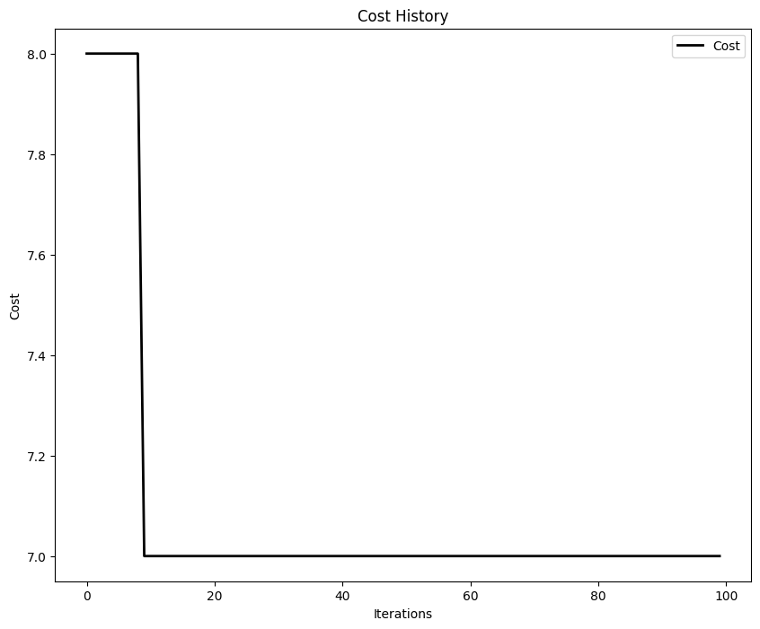

```python
num_particles = 2000
num_iterations = 100

input_strings = ['BBXMJANTEI', 'BAXIJANOEI', 'BAXIEAOPEI', 'BAXIEAOKSU', 'BUXIMQOKSU', 'BCXWMQOKSU', 'BCXWKQOKSD', 'NMXWKWOKSD', 'FMXWKWLKSF', 'FMXOKWLKTO']
num_dimensions = len(input_strings[0])
unique_chars = list(set(''.join(input_strings)))
rbounds = returnBounds(unique_chars, num_dimensions)

options = {'c1': 0.7, 'c2': 1.3, 'w':0.5}


optimizer = ps.single.GlobalBestPSO(n_particles=num_particles, dimensions=num_dimensions, options=options, bounds=rbounds)
cost, pos = optimizer.optimize(f, iters=num_iterations)

returnResultSwarms(pos, cost)

cost_history = optimizer.cost_history

plot_cost_history(cost_history)
plt.show()
```

### Output

Plot suggests that the algorithm was making progress towards finding a better solution over time. It started with 8 differences and ended with 7.  
It produced worse (-7) fitness value than genetic algorithm (-6), which may indicate that genetic algorithm works better with bigger inputs.

## Large input no. 1

```
2023-04-09 12:00:54,802 - pyswarms.single.global_best - INFO - Optimize for 100 iters with {'c1': 0.7, 'c2': 1.3, 'w': 0.5}
2023-04-09 12:01:00,611 - pyswarms.single.global_best - INFO - Optimization finished | best cost: 15.0, best pos: [0.37574169 0.44805712 0.56183351 0.24022651 0.71980617 0.71125018
 0.53860765 0.70079299 0.39151666 0.74931536 0.66920508 0.52756067
 0.64690411 0.87329762 0.38449692 0.29285013 0.40794702 0.49298197
 0.36511545 0.47156009]
```

```
Best candidate string:  RFZWTTATXUJANPXYXMRM
Fitness value of the best solution = -15
```

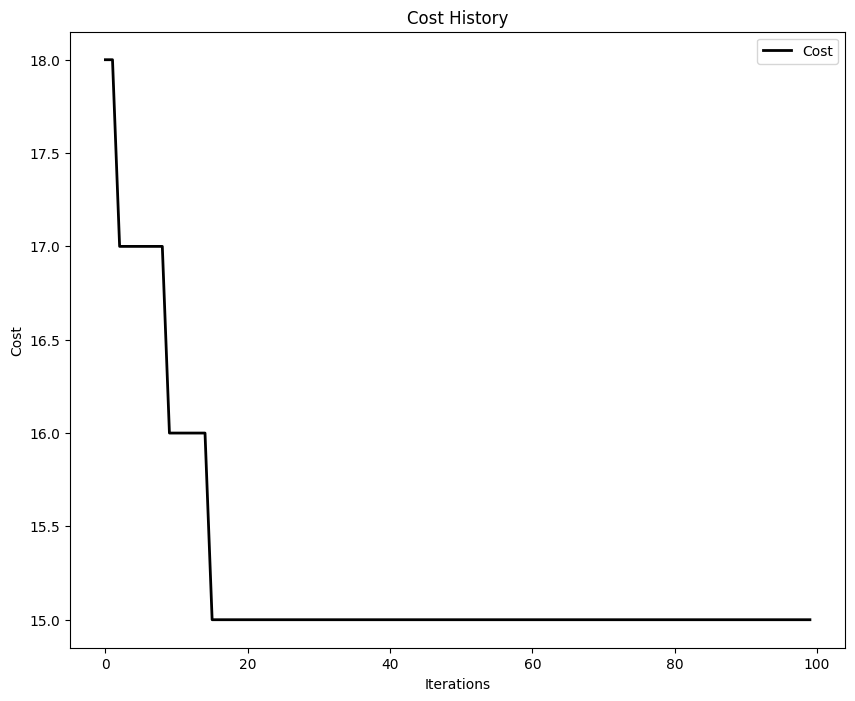

```python
num_particles = 3000
num_iterations = 100

input_strings = ['RCRAHWAYLRGANOXDXSRH', 'RCRAHWAYLRGRNPXUGSRH', 'RCRAHWAVLRGRNPWUGSRB', 'RCRNHWAVLAGXNPWUGSRO', 'RCRNHRAVLAQXNPWUPMRO', 'RCRNMRAVLAQXNPKUPMOO', 'RFRNMRITLAQXNPKUPMOO', 'RFANMRITSAQXNPKJQMOO', 'RFANMEITSAQMNPKJQMOW', 'RFANMEITXVQMNKKJQMOL', 'RFZNMEFTXVCMNKKJQMOA', 'RFHNMEUTXVCCNKKJVMOA', 'RFHNMFUTXPCCNKKJVMQA', 'RFHNAFZTXPCCNWKJVMQA', 'FFHNAFZTXPCCNWKRQMQF', 'FFUNAFZTXPCCNWKWQMSF', 'FFUNAFZTXQJXNWKWQMSN', 'FFUNAEZTXQPYNPKWQMSN', 'FFIDAEZTXCPYNCKWQMSN', 'FFIDFEZTXCPYNCKYVHSN']
num_dimensions = len(input_strings[0])
unique_chars = list(set(''.join(input_strings)))
rbounds = returnBounds(unique_chars, num_dimensions)

options = {'c1': 0.7, 'c2': 1.3, 'w':0.5}


optimizer = ps.single.GlobalBestPSO(n_particles=num_particles, dimensions=num_dimensions, options=options, bounds=rbounds)
cost, pos = optimizer.optimize(f, iters=num_iterations)

returnResultSwarms(pos, cost)
cost_history = optimizer.cost_history

plot_cost_history(cost_history)
plt.show()
```

### Output

Plot suggests that the algorithm was making progress towards finding a better solution over time. It started with 18 differences and ended with 15. It found worse solution than genetic algorithm, which returned fitness string with 13 differences.

## Large input no. 2

input_strings is defined as an array that contains 20 elements, each string has 20 characters.

```
2023-04-09 12:38:44,972 - pyswarms.single.global_best - INFO - Optimize for 100 iters with {'c1': 0.7, 'c2': 1.3, 'w': 0.5}
2023-04-09 12:38:51,064 - pyswarms.single.global_best - INFO - Optimization finished | best cost: 16.0, best pos: [0.19752045 0.68116323 0.62187235 0.28393628 0.87014704 0.50709171
 0.49085893 0.62038668 0.80760414 0.45097528 0.48107555 0.33528042
 0.12299203 0.31273341 0.71456263 0.56861481 0.2573195  0.30640111
 0.36038774 0.28309335]
```

```
Best candidate string:  CKREMLTRPYTJIJODFJZE
Fitness value of the best solution = -16
```

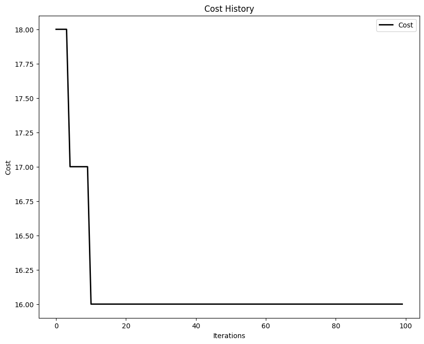

```python
num_particles = 3000
num_iterations = 100

input_strings = ['SMMEYBIXSFTVVLOVFNCD', 'SMVEYBIXGSTVVLONFWCD', 'SMVEYBCJGSTAVLONFWCJ', 'PGQEYBCJGETAVLONFWAJ', 'PGQEYBCJPETAVLANFZAP', 'PCHEYFCJPETAVLANFZVZ', 'EJHEYFCJPETAJUANFBVZ', 'CJSEYFCJPETAJQANKBVZ', 'JJSEYFCJPETAIQLQKBPZ', 'JJSEFFDRPETAIQSQKBPZ', 'JPREFIDRPEOAIQGQKBPZ', 'MPREXBDRPEOMIQGQKBPA', 'PPRGXBJRPEOMIQGQKBPU', 'PFRSXBQRPEOMIQGQXXPU', 'YTRSIBQRPEOTIQGQRXPU', 'YTRSYBTRPEOTIQTQRJPH', 'YTRSYOTRPEQTIQTTRVKH', 'YTRSWVTRPEQTIDTVPVKH', 'YJRWWVTRPOQTIDTLPVKE', 'YURWJVTRPCRTJDTLPVKE']
num_dimensions = len(input_strings[0])
unique_chars = list(set(''.join(input_strings)))
rbounds = returnBounds(unique_chars, num_dimensions)

options = {'c1': 0.7, 'c2': 1.3, 'w':0.5}


optimizer = ps.single.GlobalBestPSO(n_particles=num_particles, dimensions=num_dimensions, options=options, bounds=rbounds)
cost, pos = optimizer.optimize(f, iters=num_iterations)

returnResultSwarms(pos, cost)

cost_history = optimizer.cost_history

plot_cost_history(cost_history)
plt.show()
```

### Output

Plot suggests that the algorithm was making progress towards finding a better solution over time. It started with 18 differences and ended with 16. It found worse solution than genetic algorithm, which returned fitness string with 14 differences.

## Large input no. 3

input_strings is defined as an array that contains 20 elements, each string has 20 characters.

```
2023-04-09 12:02:54,366 - pyswarms.single.global_best - INFO - Optimize for 100 iters with {'c1': 0.7, 'c2': 1.3, 'w': 0.5}
2023-04-09 12:03:00,911 - pyswarms.single.global_best - INFO - Optimization finished | best cost: 10.0, best pos: [0.68525326 0.69495141 0.35457982 0.57024859 0.45647849 0.2322089
 0.20239238 0.79705499 0.51695474 0.56021005 0.56287763 0.17247907
 0.91696806 0.45013421 0.62381158 0.13491093 0.4400341  0.61868587
 0.33686458 0.37465448]
```

```
Best candidate string:  TURNMWOCBNNODFJVFJRX
Fitness value of the best solution = -10
```

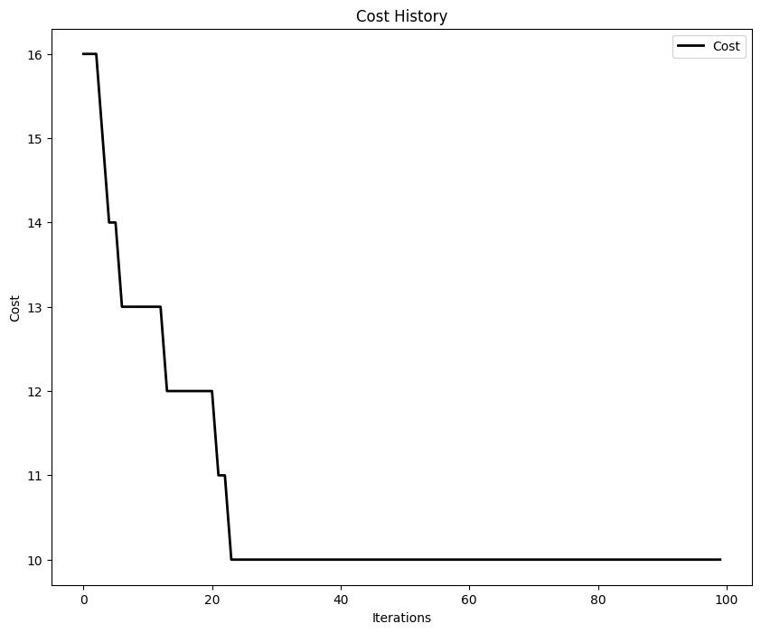

```python
num_particles = 3000
num_iterations = 100

input_strings = ['XQRNDWOCVENHQFNVFPPX', 'XQRNDWOCVENHIFNVFPPX', 'SQRNDWOCVENHIFNVFPPX', 'SQRNDWOCMENHIFNVFPPX', 'SQRNDWOCMENHMFNVFPPX', 'SQRNDWOCMENTMFNVFPPX', 'SQRNDWOCMENTLFNVFPPX', 'SURNDWOCMENTLFNVFPPX', 'SURNDWOCMENTQFNVFPPX', 'SURNDWOCMENTQBNVFPPX', 'SURNDWOCMENTQBJVFPPX', 'SURNDWOCMENTQBJVFGPX', 'SURNDWOCMENTQQJVFGPX', 'BURNDWOCMENTQQJVFGPX', 'BURNDWOTMENTQQJVFGPX', 'BURNDWOTMENOQQJVFGPX', 'BUGNDWOTMENOQQJVFGPX', 'VUGNDWOTMENOQQJVFGPX', 'VUGNDWOTDENOQQJVFGPX', 'VUGNDWOXDENOQQJVFGPX']
num_dimensions = len(input_strings[0])
unique_chars = list(set(''.join(input_strings)))
rbounds = returnBounds(unique_chars, num_dimensions)

options = {'c1': 0.7, 'c2': 1.3, 'w':0.5}


optimizer = ps.single.GlobalBestPSO(n_particles=num_particles, dimensions=num_dimensions, options=options, bounds=rbounds)
cost, pos = optimizer.optimize(f, iters=num_iterations)

returnResultSwarms(pos, cost)
cost_history = optimizer.cost_history

plot_cost_history(cost_history)
plt.show()
```

## Average time and solutions

To determine if a swarm particle algorithm is a suitable approach for our problem, we need to evaluate its accuracy and efficiency. This can be achieved by testing it on small, medium, and large inputs, and observing any decrease in accuracy rates.

```python
def averageInfoSwarms(times, solved):
    average_time = sum(times) / len(times)
    print("Average time in seconds: ", average_time)

    print("Solved "+str(solved)+"/100")
```

### Small input

In our previous observation of the input_strings ["UVWX", "XUWV", "XVWU", "UVWU", "UVXW"] we found that the best fitness value was -2. To determine the effectiveness of our algorithm, we can run it in a loop for 100 instances and increment the "solved" counter each time the cost value equals -2.

```python
num_particles = 1000
num_iterations = 50

input_strings = ["UVWX", "XUWV", "XVWU", "UVWU", "UVXW"]
num_dimensions = len(input_strings[0])
unique_chars = list(set(''.join(input_strings)))
rbounds = returnBounds(unique_chars, num_dimensions)

options = {'c1': 0.7, 'c2': 1.3, 'w':0.5}


times = []
solved = 0
for i in range(100):
    start = time.time()
    optimizer = ps.single.GlobalBestPSO(n_particles=num_particles, dimensions=num_dimensions, options=options, bounds=rbounds)
    cost, pos = optimizer.optimize(f, iters=num_iterations)
    end = time.time()
    times.append(end-start)
    if cost == 2:
        solved += 1

averageInfoSwarms(times, solved)
```

[output not shown]

[output cut: 145 more lines]

[output not shown]

```
Average time in seconds:  0.17899699449539186
Solved 100/100
```

### Results

Based on our observation of small input, we can say that the fitness function has achieved 100% accuracy. In all 100 instances, the solutions had a fitness value of -2. The average time taken by the algorithm to find the solutions is 0.17899699449539186 seconds, which suggests that the algorithm is performing a little bit slower than genetic algorithm, but it has the same accuracy in small inputs.

### Medium input

In our previous observation of the input_strings presented below, we found that the best fitness value was -8 in swarm particle algorithm and -6 in genetic algorithm, so there exists string that has only 6 differences. To determine the effectiveness of our algorithm, we can run it in a loop for 100 instances and increment the "solved" counter each time the cost value equals -6

```python
num_particles = 2000
num_iterations = 100

input_strings = ['ENVAGWCQQU', 'EIVATWZQVU', 'EAVATFRDVU', 'EXVATFXDKH', 'EXBVTJXZKH', 'EXBFLJXZZH', 'EJQFLJTZZH', 'EIQFNJTAWH', 'EREFJJTAFH', 'ELBPJITAFH']
num_dimensions = len(input_strings[0])
unique_chars = list(set(''.join(input_strings)))
rbounds = returnBounds(unique_chars, num_dimensions)

options = {'c1': 0.7, 'c2': 1.3, 'w':0.5}


times = []
solved = 0
for i in range(100):
    start = time.time()
    optimizer = ps.single.GlobalBestPSO(n_particles=num_particles, dimensions=num_dimensions, options=options, bounds=rbounds)
    cost, pos = optimizer.optimize(f, iters=num_iterations)
    end = time.time()
    times.append(end-start)
    if cost == 6:
        solved += 1

averageInfoSwarms(times, solved)
```

[output not shown]

[output cut: 245 more lines]

[output not shown]

```
Average time in seconds:  1.5738956904411316
Solved 0/100
```

### Results

As we can see, our algorithm has found 0 results and genetic algorithm has identified 32 potential solutions. To expand our search, we will increase the searched cost to 7 and evaluate how many solutions are discovered.

```python
num_particles = 2000
num_iterations = 100

input_strings = ['ENVAGWCQQU', 'EIVATWZQVU', 'EAVATFRDVU', 'EXVATFXDKH', 'EXBVTJXZKH', 'EXBFLJXZZH', 'EJQFLJTZZH', 'EIQFNJTAWH', 'EREFJJTAFH', 'ELBPJITAFH']
num_dimensions = len(input_strings[0])
unique_chars = list(set(''.join(input_strings)))
rbounds = returnBounds(unique_chars, num_dimensions)

options = {'c1': 0.7, 'c2': 1.3, 'w':0.5}


times = []
solved = 0
for i in range(100):
    start = time.time()
    optimizer = ps.single.GlobalBestPSO(n_particles=num_particles, dimensions=num_dimensions, options=options, bounds=rbounds)
    cost, pos = optimizer.optimize(f, iters=num_iterations)
    end = time.time()
    times.append(end-start)
    if cost == 7:
        solved += 1

averageInfoSwarms(times, solved)
```

[output not shown]

[output cut: 245 more lines]

[output not shown]

```
Average time in seconds:  1.4133725214004516
Solved 50/100
```

When searched cost is increased to 7 we have 50% accuracy. Despite this improvement, the genetic algorithm still outperforms our method by discovering a string with a lower count of different characters.

### Large input

```python
num_particles = 3000
num_iterations = 100

input_strings = ['XQRNDWOCVENHQFNVFPPX', 'XQRNDWOCVENHIFNVFPPX', 'SQRNDWOCVENHIFNVFPPX', 'SQRNDWOCMENHIFNVFPPX', 'SQRNDWOCMENHMFNVFPPX', 'SQRNDWOCMENTMFNVFPPX', 'SQRNDWOCMENTLFNVFPPX', 'SURNDWOCMENTLFNVFPPX', 'SURNDWOCMENTQFNVFPPX', 'SURNDWOCMENTQBNVFPPX', 'SURNDWOCMENTQBJVFPPX', 'SURNDWOCMENTQBJVFGPX', 'SURNDWOCMENTQQJVFGPX', 'BURNDWOCMENTQQJVFGPX', 'BURNDWOTMENTQQJVFGPX', 'BURNDWOTMENOQQJVFGPX', 'BUGNDWOTMENOQQJVFGPX', 'VUGNDWOTMENOQQJVFGPX', 'VUGNDWOTDENOQQJVFGPX', 'VUGNDWOXDENOQQJVFGPX']
num_dimensions = len(input_strings[0])
unique_chars = list(set(''.join(input_strings)))
rbounds = returnBounds(unique_chars, num_dimensions)

options = {'c1': 0.7, 'c2': 1.3, 'w':0.5}


times = []
solved = 0
for i in range(100):
    start = time.time()
    optimizer = ps.single.GlobalBestPSO(n_particles=num_particles, dimensions=num_dimensions, options=options, bounds=rbounds)
    cost, pos = optimizer.optimize(f, iters=num_iterations)
    end = time.time()
    times.append(end-start)
    if cost == 6:
        solved += 1

averageInfoSwarms(times, solved)
```

[output not shown]

[output cut: 445 more lines]

[output not shown]

```
Average time in seconds:  5.836058101654053
Solved 0/100
```

```python
num_particles = 3000
num_iterations = 100

input_strings = ['XQRNDWOCVENHQFNVFPPX', 'XQRNDWOCVENHIFNVFPPX', 'SQRNDWOCVENHIFNVFPPX', 'SQRNDWOCMENHIFNVFPPX', 'SQRNDWOCMENHMFNVFPPX', 'SQRNDWOCMENTMFNVFPPX', 'SQRNDWOCMENTLFNVFPPX', 'SURNDWOCMENTLFNVFPPX', 'SURNDWOCMENTQFNVFPPX', 'SURNDWOCMENTQBNVFPPX', 'SURNDWOCMENTQBJVFPPX', 'SURNDWOCMENTQBJVFGPX', 'SURNDWOCMENTQQJVFGPX', 'BURNDWOCMENTQQJVFGPX', 'BURNDWOTMENTQQJVFGPX', 'BURNDWOTMENOQQJVFGPX', 'BUGNDWOTMENOQQJVFGPX', 'VUGNDWOTMENOQQJVFGPX', 'VUGNDWOTDENOQQJVFGPX', 'VUGNDWOXDENOQQJVFGPX']
num_dimensions = len(input_strings[0])
unique_chars = list(set(''.join(input_strings)))
rbounds = returnBounds(unique_chars, num_dimensions)

options = {'c1': 0.7, 'c2': 1.3, 'w':0.5}


times = []
solved = 0
for i in range(100):
    start = time.time()
    optimizer = ps.single.GlobalBestPSO(n_particles=num_particles, dimensions=num_dimensions, options=options, bounds=rbounds)
    cost, pos = optimizer.optimize(f, iters=num_iterations)
    end = time.time()
    times.append(end-start)
    if cost == 7:
        solved += 1

averageInfoSwarms(times, solved)
```

[output not shown]

[output cut: 446 more lines]

[output not shown]

```
Average time in seconds:  6.085924663543701
Solved 0/100
```

```python
num_particles = 3000
num_iterations = 100

input_strings = ['XQRNDWOCVENHQFNVFPPX', 'XQRNDWOCVENHIFNVFPPX', 'SQRNDWOCVENHIFNVFPPX', 'SQRNDWOCMENHIFNVFPPX', 'SQRNDWOCMENHMFNVFPPX', 'SQRNDWOCMENTMFNVFPPX', 'SQRNDWOCMENTLFNVFPPX', 'SURNDWOCMENTLFNVFPPX', 'SURNDWOCMENTQFNVFPPX', 'SURNDWOCMENTQBNVFPPX', 'SURNDWOCMENTQBJVFPPX', 'SURNDWOCMENTQBJVFGPX', 'SURNDWOCMENTQQJVFGPX', 'BURNDWOCMENTQQJVFGPX', 'BURNDWOTMENTQQJVFGPX', 'BURNDWOTMENOQQJVFGPX', 'BUGNDWOTMENOQQJVFGPX', 'VUGNDWOTMENOQQJVFGPX', 'VUGNDWOTDENOQQJVFGPX', 'VUGNDWOXDENOQQJVFGPX']
num_dimensions = len(input_strings[0])
unique_chars = list(set(''.join(input_strings)))
rbounds = returnBounds(unique_chars, num_dimensions)

options = {'c1': 0.7, 'c2': 1.3, 'w':0.5}


times = []
solved = 0
for i in range(100):
    start = time.time()
    optimizer = ps.single.GlobalBestPSO(n_particles=num_particles, dimensions=num_dimensions, options=options, bounds=rbounds)
    cost, pos = optimizer.optimize(f, iters=num_iterations)
    end = time.time()
    times.append(end-start)
    if cost == 8:
        solved += 1

averageInfoSwarms(times, solved)
```

[output not shown]

[output cut: 446 more lines]

[output not shown]

```
Average time in seconds:  6.087517635822296
Solved 4/100
```

## Time and accuracy

To determine the optimal algorithm for a given problem, we will compare the performance of genetic and PSO algorithms through the use of plots.

### Time

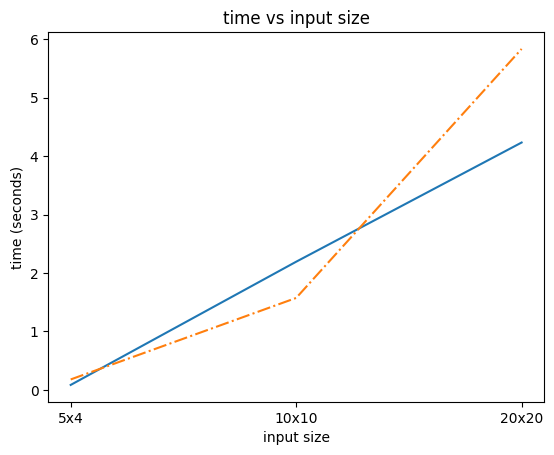

```python
x = ['5x4', '10x10', '20x20']
geneticTime = [0.08530545473098755, 2.1938141703605654, 4.234085736274719]
swarmsTime = [0.17899699449539186, 1.5738956904411316, 5.836058101654053]

plt.plot(x, geneticTime)
plt.plot(x, swarmsTime, '-.')

plt.xlabel("input size")
plt.ylabel("time (seconds)")
plt.title('time vs input size')
plt.show()
```

### Accuracy

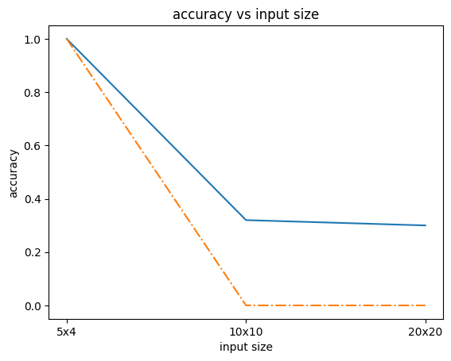

```python
x = ['5x4', '10x10', '20x20']
geneticAcc = [1, 0.32, 0.3]
swarmsAcc = [1, 0, 0]

plt.plot(x, geneticAcc)
plt.plot(x, swarmsAcc, '-.')

plt.ylabel("accuracy")
plt.xlabel("input size")
plt.title('accuracy vs input size')
plt.show()
```

# Conclusions

Upon analyzing the performance of two algorithms, Genetic Algorithm (GA) and Particle Swarm Optimization (PSO), for a given problem with varying input sizes, we can observe interesting trends.

For small input sizes, both GA and PSO exhibit a 100% accuracy rate in finding the optimal solution. However, the time taken by GA is comparatively better than that of PSO.

As we move on to medium-sized inputs, we notice that GA outperforms PSO in terms of finding a better solution with a smaller Hamming distance, but PSO is faster than GA in this case.

# Bibliography

https://en.wikipedia.org/wiki/Closest_string

https://en.wikipedia.org/wiki/Hamming_distance

https://pl.frwiki.wiki/wiki/Cha%C3%AEne_la_plus_proche

https://link.springer.com/chapter/10.1007/978-3-540-78839-3_33